# Instructions conditionnelles et expression booléennes

Dans l'exemple du calcul de vitesse d'un coureur, on a automatisé une séquence de calculs assez simples, et dont le déroulement est *toujours le même*.

Il y a d'autres problèmes, où le processus de résolution sera différent selon les données d'entrée. Par exemple, pour calculer la valeur absolue d'un nombre, le processus est différent selon si le nombre est positif ou négatif.

Afin de pouvoir sélectionner des opérations différentes selon la valeur des données, on utilise des **branchements conditionnels**: le terme *branchement* suggère qu'on arrive à une intersection et on décide de tourner à droite ou à gauche en utilisant un mécanisme de décision. En Java ce mécanisme se matérialise par les instructions conditionnnelles `if` et `switch`.

## Instructions conditionnelles avec `if`

Commençons par l'exemple de la valeur absolue. On va écrire un petit programme où l'utilisateur entre un nombre, et le programme affiche la valeur absolue du nombre.

Commençons par lire le nombre au clavier. On va utiliser le type `double` pour que l'utilisateur puisse entrer un entier ou un décimal:

```java
import java.util.Scanner;
Scanner clavier = new Scanner(System.in);

System.out.println("Entrer un nombre quelconque:");
double nombre = clavier.nextDouble();
```

```
Entrer un nombre quelconque:
23.66
```

Le processus conditionnel est le suivant:

- **si** (le nombre est positif ou nul) **alors**:  
  on affiche le nombre lui-même.
- **sinon**:  
  on affiche l'opposé du nombre.

En Java on écrit:

```java
if (nombre >=0) {
    System.out.printf("La valeur absolue du nombre est: %f", nombre);
} else {
    System.out.printf("La valeur absolue du nombre est: %f", -nombre);
}
```

```
La valeur absolue du nombre est: 23.660000
```

Voyons plus en détail l'instruction conditionnelle `if` qu'on vient d'utiliser:

```
if (condition) {
    instruction 1
} else {
    instructions 2
}
```

Si la condition est *vraie*, alors l'instruction 1 est exécutée, et l'instruction 2 est sautée. Si, en revanche, la condition est *fausse*, alors l'instruction 1 est sautée et l'instruction 2 est exécutée.

Les éléments clés d'une instruction conditionnelle:

- la `condition` est une **expression booléenne**, c'est-à-dire une expression dont le résultat peut prendre seulement les valeurs *vrai* ou *faux*. Par exemple: `nombre >= 0`.
- la clause `else` est optionnelle: on peut écrire simplement:

  ```
  instruction 1
  if (condition) {
    instructions 2
  }
  instruction 3
  ```

  Si la `condition` est vraie, alors les trois instructions sont exécutées dans l'ordre. Si la `condition` est fausse, on saute l'instruction 2 et on exécute simplement :

  ```
  instruction 1
  instruction 3
  ```

- Ici on a encadré les instructions après le `if` et après le `else` par des accolades `{` et `}`. Ces accolades permettent en fait de délimiter des *blocs* d'instructions, et sont optionnelles quand le bloc comporte une seule instruction (comme ici). C'est une bonne pratique de toujours les mettre tout de même, ça peut éviter des erreurs.
- Pour améliorer la lisibilité d'un programme, on *indente* habituellement les blocs d'instructions (on place une tabulation en début de ligne). Ceci permet de voir la structure du code au premier coup d'oeil. Cependant, l'indentation ne change rien au fonctionnement du programme (à noter que dans certains langages, notamment Python, l'indentation affecte le sens d'un programme).

On va aborder ces différents éléments plus en détail, à partir d'exemples.

### Exemple: `if` sans `else`

Dans notre exemple de la valeur absolue, on aurait pu se débrouiller sans la clause `else`: on aurait pu (toujours) afficher le contenu de la variable `nombre`, dont on aurait simplement modifié la valeur si elle était négative.

```java
System.out.println("Entrer un nombre quelconque:");
nombre = clavier.nextDouble();
if (nombre<0){             // si le nombre est négatif, alors
    nombre = -nombre;      // on remplace le nombre par son opposé
}
System.out.printf("La valeur absolue du nombre est: %f", nombre);
```

```
Entrer un nombre quelconque:
-13.5
La valeur absolue du nombre est: 13.500000
```

```
java.io.PrintStream@1d9fd349
```

Pour un nombre positif, on aurait simplement sauté l'instruction qui remplace `nombre` par son opposé. Remarquer que la condition évalue cette fois si `nombre` est *négatif*, puisque dans le cas où `nombre` est positif on n'a rien à faire.

On aurait pu aussi écrire:

```java
if (nombre>=0){
} else {
    nombre = -nombre;
}
```

Ici après le `if` on a une instruction vide (c'est à dire rien entre les accolades), et donc si la condition est vraie on ne fait rien. Cela dit, cette écriture est un peu maladroite et il est plus "propre" d'écrire un `if` utilisant la condition contraire, et sans `else`.

#### Exercice 1

Le code suivant permet à l'utilisateur d'entrer deux nombres. Ajouter une instruction conditionnelle `if` pour que le programme affiche ensuite **le plus grand des deux nombres**.

```java
System.out.println("Entrer deux nombres séparés d'un espace:");
double n1 = clavier.nextDouble();
double n2 = clavier.nextDouble();
double max = 0;

// if ici

System.out.println("Le plus grand des deux nombres est: " + max);
```

```
Entrer deux nombres séparés d'un espace:
11.3  -5
Le plus grand des deux nombres est: 0.0
```

### Exemple: un calcul conditionnel plus complexe

Comme on l'a dit plus haut, dans le problème de calculer la vitesse d'un coureur, le processus est toujours le même. On va détailler ici un autre calcul un peu complexe, qui inclut un branchement conditionnel.

#### Hydro-Québec

On veut automatiquement calculer le montant à payer à Hydro-Québec pour une certaine consommation d'électricité. Ce montant est calculé comme indiqué sur le site d'Hydro-Québec:

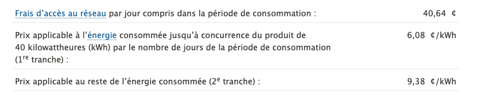

Le fait que deux tarifs existent, et qu'un des tarifs ne s'applique qu'à partir d'une certaine consommation, implique que le calcul peut se faire de deux manières différentes, selon si la consommation est basse ou plus élevée.

On va d'abord détailler les étapes du calcul sur un exemple, puis reprendre ces étapes dans un programme qui automatise ce calcul, avec une instruction conditionnelle.

Supposons qu'on a consommé **2850 kWh** sur une période de **56 jours**. On va stocker ces données d'entrée dans des variables:

```java
double conso = 2850;
int jours = 56;
```

Calculons les frais d'accès au réseau:

```java
double frais = 0.4064 * jours;
```

Pour calculer le montant à payer pour l'*énergie consommée*, on calcule déjà le maximum d'énergie qui constitue la "première tranche": 40 kWh multiplié par le nombre de jours:

```java
double maxT1 = 40 * jours;

System.out.println("max premiere tranche:" + maxT1);
```

```
max premiere tranche:2240.0
```

Ici on doit regarder le résultat, et prendre une décision: si notre consommation est en-dessous de cette limite, on payerait toute notre consommation au tarif bas. Si notre consommation dépasse la limite, on doit séparer notre consommation en deux tranches: on paye le tarif bas pour la première, et le tarif plus élevé pour la deuxième.

Ici, on est dans le deuxième cas: notre consommation (2850 kWh) dépasse le montant alloué pour la première tranche (2240 kWh).

Le calcul est donc:

```java
double tranche1 = maxT1 * 0.0608;

double tranche2 = (conso - maxT1) * 0.0938;

System.out.println(" Tranche 1: " + tranche1 + "\n tranche 2: " + tranche2);
```

```
 Tranche 1: 136.192
 tranche 2: 57.217999999999996
```

On paye \$136.19 pour la première tranche (2240 kWh à \\$0.0608 par kWh) et \$57.22 pour la deuxième tranche (610 kWh à \0.0938 par kWh).

Il faut enfin ajouter les taxes (14.975%, non indiqué sur l'image ci-dessus). Le total à payer est donc:

```java
(frais + tranche1 + tranche2)*1.14975
```

```
248.5396179
```

Notre facture totale sera donc de $248.54.

Comment ferait-on le calcul si la consommation était faible et n'utilisait que le tarif bas?

Prenons un autre exemple. Toujours sur 56 jours, on a cette fois utilisé seulement **1100 kwh**:

```java
double conso = 1100;
```

Les frais restent les mêmes, mais les montants pour les deux tranches sont différents: comme on est en-dessous du maximum de la première tranche, on paye toute notre consommation au tarif bas:

```java
tranche1 = conso * 0.0608;
tranche2 = 0;
```

On recalcule le montant final après taxes:

```java
(frais + tranche1 + tranche2)*1.14975
```

```
103.0617504
```

On va maintenant automatiser ce calcul dans un petit programme, dans lequel on aura une **instruction conditionnelle** qui nous permettra de calculer la facture comme dans le premier cas ou comme dans le deuxième.

Cette fois on va permettre à l'utilisateur de donner les données d'entrée au clavier:

```java
System.out.println("Calcul d'une facture Hydro-Québec:");
System.out.println("Entrer l'énergie consommée:");
conso = clavier.nextDouble();
System.out.println("Entrer le nombre de jours:");
jours = clavier.nextInt();
```

```
Calcul d'une facture Hydro-Québec:
Entrer l'énergie consommée:
2850
Entrer le nombre de jours:
56
```

Les premiers calculs:

```java
frais = 0.4064 * jours;
maxT1 = 40* jours;
```

**Si** la consommation (`conso`) dépasse `maxT1` **alors** on va calculer le montant à payer comme ceci:

```
tranche1 = maxT1 * 0.0608
tranche2 = (conso - maxT1) * 0.0938
```

**Sinon** on va calculer le montant à payer simplement comme cela:

```
tranche1 = conso * 0.0608
tranche2 = 0
```

En Java on écrit donc:

```java
double conso1;
if (conso > maxT1){
    tranche1 = maxT1 * 0.0608;
    tranche2 = (conso - maxT1) * 0.0938;
} else {
    tranche1 = conso * 0.0608;
    tranche2 = 0;
}
```

On termine par le montant total après taxes, qui se calcule de la même façon dans les deux cas:

```java
double facture = (frais + tranche1 + tranche2) * 1.14975;

System.out.printf("Le montant de la facture sera de $%.2f", facture);
```

```
Le montant de la facture sera de $248.54
```

```
java.io.PrintStream@1d9fd349
```

On obtient bien le même résultat. Le même programme peut être utilisé pour calculer les montants de factures pour d'autres consommations et périodes de jours.

#### Exercice 2

Supposons qu'un autobus passe toutes les heures dans une certaine rue, 12 minutes après l'heure: 0h12, 1h12, 2h12, etc. Comléter le programme ci-dessous qui demande l'heure à l'utilisateur, puis affiche le nombre de minutes à attendre pour l'autobus.

Indication: le calcul est différent selon si il est plus ou moins de 12 minutes après l'heure.

```java
System.out.println("Quelle heure est-il? (heures puis minutes)");
int heures = clavier.nextInt();
int minutes = clavier.nextInt();

System.out.println("L'autobus arrive dans 24 minutes.");
```

```
Quelle heure est-il? (heures puis minutes)
10 47
L'autobus arrive dans 24 minutes.
```